# Video Game Sales Investment Study

Matthew Afoakwah, Chris Weiner, Jaye Evans

March 28th, 2023

## 1. Scenerio

Suppose their is an investor who wants to invest in a gaming platform. However before the investor invests, they want to know which gaming platform between the years 2010 to 2016 has the best NA, EU, and Global sales. The investor also wants to know what video game category produces the most income between 2010 and 2016 while for each video game platform so that they can better invest their money to better profit themselves in the future.The investor also wants to see what developers create more profitable games and the video game categories those developers mainly develop. The investor wants an indepth analyst on the video game platforms, video game categories, and developers before they invest their money.

## 2.Preparation

The data we are using was uploaded to Kaggle by SID_TWR. SID_TWR stated that this dataset was scraped from VGChartz and Metacritic.

2.1 Load Tidyverse package Before we work on our data we first want to load it into R, but first we must add two R packages into R before we attempt to work with data.

```r
# install.packages('Tidyverse')
library(formatR)
library(tidyverse)  #Used to load tidyverse package into R.
library(readr)  #Used to load readr package in R to use to read CSV file.
```

2.2 Import dataset  
Now we want to use import our dataset into R using the read_CSV function that is from our readr package.

```r
# Reads the CSV file from the file location using read_csv, and imports the
# file into R, named Video_Games_Sales
Video_Games_Sales <- read_csv("data/Video_Games_Sales_as_at_22_Dec_2016.csv")
```

2.3 Preview dataset Before we can work on our dataset, we must first see if the dataset is relivant to our task. In order to accomplish this we must explore the dataset in R.

```r
# we use the head() function to get a preview of the dataset.
head(Video_Games_Sales)
```

```
## # A tibble: 6 × 16
##   Name     Platf…¹ Year_…² Genre Publi…³ NA_Sa…⁴ EU_Sa…⁵ JP_Sa…⁶ Other…⁷ Globa…⁸
##   <chr>    <chr>   <chr>   <chr> <chr>     <dbl>   <dbl>   <dbl>   <dbl>   <dbl>
## 1 Wii Spo… Wii     2006    Spor… Ninten…    41.4   29.0     3.77    8.45    82.5
## 2 Super M… NES     1985    Plat… Ninten…    29.1    3.58    6.81    0.77    40.2
## 3 Mario K… Wii     2008    Raci… Ninten…    15.7   12.8     3.79    3.29    35.5
## 4 Wii Spo… Wii     2009    Spor… Ninten…    15.6   10.9     3.28    2.95    32.8
## 5 Pokemon… GB      1996    Role… Ninten…    11.3    8.89   10.2     1       31.4
## 6 Tetris   GB      1989    Puzz… Ninten…    23.2    2.26    4.22    0.58    30.3
## # … with 6 more variables: Critic_Score <dbl>, Critic_Count <dbl>,
## #   User_Score <dbl>, User_Count <dbl>, Developer <chr>, Rating <chr>, and
## #   abbreviated variable names ¹Platform, ²Year_of_Release, ³Publisher,
## #   ⁴NA_Sales, ⁵EU_Sales, ⁶JP_Sales, ⁷Other_Sales, ⁸Global_Sales
```

We have now seen some of the data set but before we can verify that the data set is relevant we must explore the data set further. To accomplish this we use the glimpse() function

```r
# shows a glimpse of the data set along with the attributes.
glimpse(Video_Games_Sales)
```

```
## Rows: 16,719
## Columns: 16
## $ Name            <chr> "Wii Sports", "Super Mario Bros.", "Mario Kart Wii", "…
## $ Platform        <chr> "Wii", "NES", "Wii", "Wii", "GB", "GB", "DS", "Wii", "…
## $ Year_of_Release <chr> "2006", "1985", "2008", "2009", "1996", "1989", "2006"…
## $ Genre           <chr> "Sports", "Platform", "Racing", "Sports", "Role-Playin…
## $ Publisher       <chr> "Nintendo", "Nintendo", "Nintendo", "Nintendo", "Ninte…
## $ NA_Sales        <dbl> 41.36, 29.08, 15.68, 15.61, 11.27, 23.20, 11.28, 13.96…
## $ EU_Sales        <dbl> 28.96, 3.58, 12.76, 10.93, 8.89, 2.26, 9.14, 9.18, 6.9…
## $ JP_Sales        <dbl> 3.77, 6.81, 3.79, 3.28, 10.22, 4.22, 6.50, 2.93, 4.70,…
## $ Other_Sales     <dbl> 8.45, 0.77, 3.29, 2.95, 1.00, 0.58, 2.88, 2.84, 2.24, …
## $ Global_Sales    <dbl> 82.53, 40.24, 35.52, 32.77, 31.37, 30.26, 29.80, 28.92…
## $ Critic_Score    <dbl> 76, NA, 82, 80, NA, NA, 89, 58, 87, NA, NA, 91, NA, 80…
## $ Critic_Count    <dbl> 51, NA, 73, 73, NA, NA, 65, 41, 80, NA, NA, 64, NA, 63…
## $ User_Score      <dbl> 8.0, NA, 8.3, 8.0, NA, NA, 8.5, 6.6, 8.4, NA, NA, 8.6,…
## $ User_Count      <dbl> 322, NA, 709, 192, NA, NA, 431, 129, 594, NA, NA, 464,…
## $ Developer       <chr> "Nintendo", NA, "Nintendo", "Nintendo", NA, NA, "Ninte…
## $ Rating          <chr> "E", NA, "E", "E", NA, NA, "E", "E", "E", NA, NA, "E",…
```

Now we want to look at all the columns within the data set. We accomplish this using the colnames() function.

```r
# Shows the name of the columns in the Video_Games_Sales data set.
colnames(Video_Games_Sales)
```

```
##  [1] "Name"            "Platform"        "Year_of_Release" "Genre"
##  [5] "Publisher"       "NA_Sales"        "EU_Sales"        "JP_Sales"
##  [9] "Other_Sales"     "Global_Sales"    "Critic_Score"    "Critic_Count"
## [13] "User_Score"      "User_Count"      "Developer"       "Rating"
```

Now we want to determine the size of the data set so we use the dim() function to determine the data sets size

```r
# After using the dim() function we see that the length of the data set is 16
# and that there is 16719 rows.
dim(Video_Games_Sales)
```

```
## [1] 16719    16
```

To continue our exploration we wish to see the data type of each column, in order to accomplish this we use the class function.

```r
# We use the sapply() function to apply the class function on each attribute of
# our data set.
sapply(Video_Games_Sales, class)
```

```
##            Name        Platform Year_of_Release           Genre       Publisher
##     "character"     "character"     "character"     "character"     "character"
##        NA_Sales        EU_Sales        JP_Sales     Other_Sales    Global_Sales
##       "numeric"       "numeric"       "numeric"       "numeric"       "numeric"
##    Critic_Score    Critic_Count      User_Score      User_Count       Developer
##       "numeric"       "numeric"       "numeric"       "numeric"     "character"
##          Rating
##     "character"
```

From viewing our data set we see that our data set is relevant to our task and has given us insight to our data set which will allow us to move on to the next step.

## 3. Data Cleaning

Though we can see that our data set has information that can be used for our problem there is also irrelevant data in the data set, in order to focus on the information that we need we will need to clean the data set using transformations.

```r
# use the filter() function to remove all rows where the release year is not
# between 2010 and 2016. Then we store it in a new data set called
# gamesales2010_2016
gamesales2010_2016 <- filter(Video_Games_Sales, Year_of_Release >= 2010)
# We use the dim() function and see that the amount of rows in the data set.
dim(gamesales2010_2016)
```

```
## [1] 5550   16
```

3.2 We will now filter all rows where the Year_of_Release is unknown.

```r
# The filter() function removes all values that are 'N/A' in the
# Year_of_Release column
gamesales2010_2016 <- filter(gamesales2010_2016, Year_of_Release != "N/A")
# nrow() prints out the number of rows in gamesales2010_2016.
nrow(gamesales2010_2016)
```

```
## [1] 5281
```

We have decided to remove all rows where the Year_of_Release is “N/A” because there are not too much “N/A” value’s missing in the Year_of_Release column which would greatly impact our data set, because of this we are able to easily remove the “N/A” values from the data set without having to worry about our results being greatly influenced.

3.3 We want to find and remove any duplicated files so we use the duplicated() function.

```r
# We use the duplicated() to find all rows where they are repeated occurences.
# #Then we use the ! to filter them out from the graph.
gamesales2010_2016 <- gamesales2010_2016[!duplicated(gamesales2010_2016), ]
# We use #nrow() function to see the amount of rows left in the data set.
nrow(gamesales2010_2016)
```

```
## [1] 5281
```

After checking/removing all duplicated files in the data set we see view how many rows are in the data set. We notice that the number of rows did not decrease so there were no repeated values in the dataset.

3.4 We want to identify any outliers that are in our data set before we can continue any further. To accomplish this what we want to do is use a boxplot graph to identify any outliers in the graph. Because the numeric columns we will be focusing on are Global and NA Sales we will only look for outliers in these two columns.

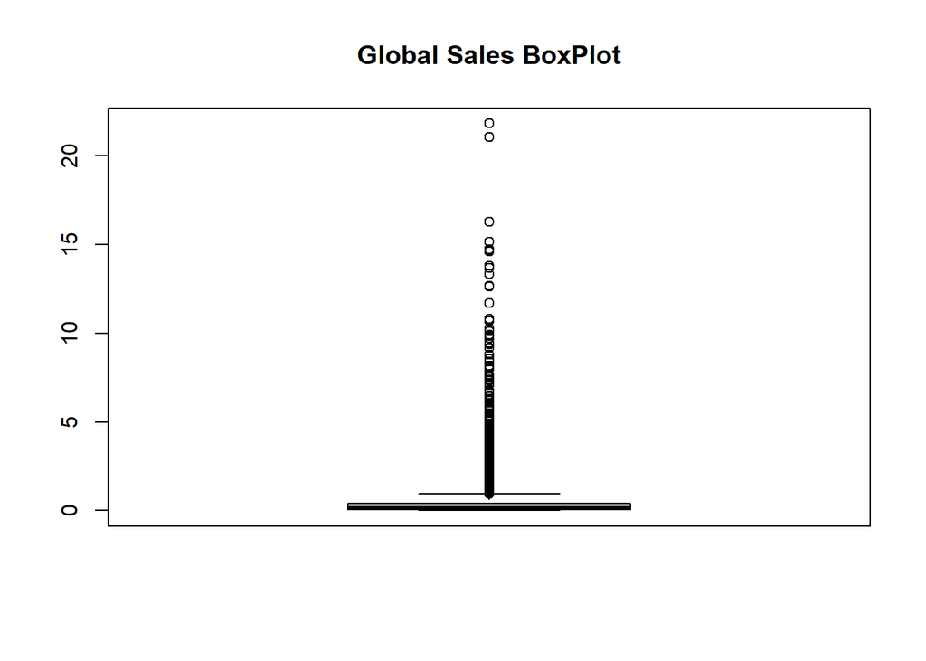

```r
# We create a boxplot for the Global Sales in gamesales_2010_2016 then set the
# title to 'Global Sales BoxPlot'.
boxplot(gamesales2010_2016$Global_Sales, main = "Global Sales BoxPlot")
```

```r
# We create a new variable outliers, then use boxplot.stats() to assign our
# outliers from Global sales to outliers.
outliers <- boxplot.stats(gamesales2010_2016$Global_Sales)$out
```

This boxplot creates a visual representation of the max, min, and median values in the Global sales of our data set.

We can see that there are some outliers in the Global Sales, this allows us to easily remove them from our data set. However we will not remove them as they will also not affect our progress moving forward. Now, we will check the outliers for the NA Sales.

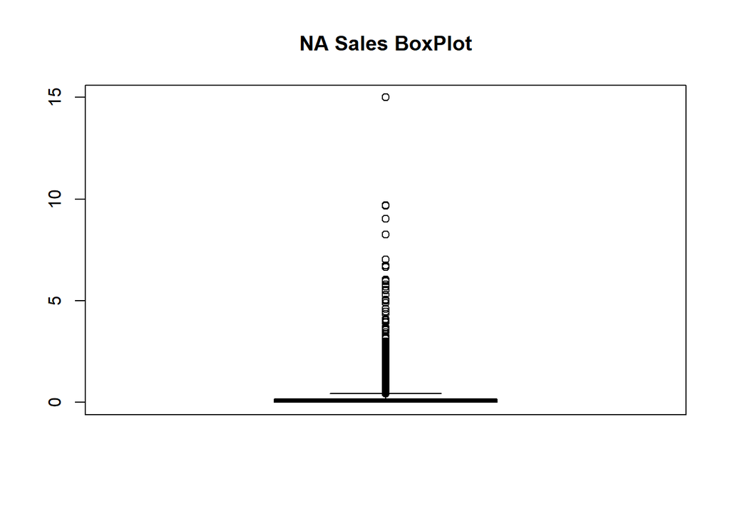

```r
# We create a boxplot for the NA Sales in gamesales_2010_2016 then set the
# title to 'NA Sales BoxPlot'.
boxplot(gamesales2010_2016$NA_Sales, main = "NA Sales BoxPlot")
```

```r
# We create a new variable outliersNA, then use boxplot.stats() to assign our
# outliers from NA sales to outliersNA.
outliersNA <- boxplot.stats(gamesales2010_2016$NA_Sales)$out
```

This boxplot creates a visual representation of the max, min, and median values in the NA sales of our data set.

In this data set outliers are usually the top selling games or the ones that sell very little. This is why we did not remove any outliers, as it is valuable data and is relevant to what we will be searching for in the data set.

## 4. Data Exploration

We now develop questions to explore the data set even further.

1. Which video game platform made the most NA Sales from 2010 to 2016?
2. Which video game platform made the most Global Sales from 2010 to 2016?
3. Which video game category had the highest NA sales?
4. Which video game category made the highest Global sales?
5. Which top five video game developers have the highest Global video game sales?
6. Which video game genre is the top five developers most profitable in?

4.1 Before we can go and answer the questions we first want to explore the unique attributes in the platform column to see if there are any discrepancies that need to be fixed.

```r
# unique function lists the unique characters in the platform column.
unique(gamesales2010_2016$Platform)
```

```
##  [1] "X360" "PS3"  "DS"   "PS4"  "3DS"  "Wii"  "XOne" "WiiU" "PC"   "PSP"
## [11] "PSV"  "PS2"
```

From looking at the unique attributes in the platform column we do not have any irregularities that might need to be rewritten and we can now continue to answer the first question.

4.2 In order to answer the first question we must calculate the NA revenue for each platform.

```r
# We move the gamesales2010_2016 data into a new data set.
platform_NA_Sales <- gamesales2010_2016 %>%
    # We use the group_by() to group all the platforms in the platform_NA_Sales
    # together.
group_by(Platform) %>%
    # We use the summarize() to summarize the sum of NA_sales for each
    # different platform.
summarize(NA_total = sum(NA_Sales)) %>%
    # We arrange the data set by decreasing order according to the NA_total.
arrange(desc(NA_total))
# We use the head() function to preview the new data set.
head(platform_NA_Sales)
```

```
## # A tibble: 6 × 2
##   Platform NA_total
##   <chr>       <dbl>
## 1 X360        334.
## 2 PS3         229.
## 3 Wii         121.
## 4 PS4         109.
## 5 XOne         93.1
## 6 3DS          82.6
```

What this code does is that it sums up the total NA sales made between 2010 to 2016 for each video game platform. We create another table which calculates the NA and Global sales for each platform for everty different year as well.

```r
# We move the gamesales2010_2016 data into a new data set.
platform_SalesbyYear <- gamesales2010_2016 %>%
    # We use the group_by() to group all the Platform and Year_of_Release
    # together.
group_by(Platform, Year_of_Release) %>%
    # We use the summarize() to summarize the sum of NA_sales for each
    # different platform, and year.
summarize(NA_total = sum(NA_Sales), glbl_total = sum(Global_Sales)) %>%
    # We arrange the data set by decreasing order according to the glbl_total.
arrange(desc(glbl_total))
# We use the head() function to preview the new data set.
head(platform_SalesbyYear)
```

```
## # A tibble: 6 × 4
## # Groups:   Platform [4]
##   Platform Year_of_Release NA_total glbl_total
##   <chr>    <chr>              <dbl>      <dbl>
## 1 X360     2010               107.        170.
## 2 PS3      2011                64.9       157.
## 3 X360     2011                86.8       144.
## 4 PS3      2010                61.0       142.
## 5 Wii      2010                72.6       128.
## 6 PS4      2015                42.4       119.
```

What this code does is that it calculates the total NA and Global sales of each platform based on the year. This will allow us to find a trend in the profit of each platform.

4.3 Secondly, we calculate the global revenue for each platform.

```r
# We move the gamesales2010_2016 data into a new data set then pipe the
# command.
platform_glbl_sales <- gamesales2010_2016 %>%
    # We use the group_by() to group all the platforms together.
group_by(Platform) %>%
    # We use the summarize function to summarize the sum of Global_sales for
    # each different platform.
summarize(glbl_total = sum(Global_Sales)) %>%
    # We arrange the data set by decreasing order according to the glbl_total.
arrange(desc(glbl_total))
# We use the head() function to preview the table.
head(platform_glbl_sales)
```

```
## # A tibble: 6 × 2
##   Platform glbl_total
##   <chr>         <dbl>
## 1 PS3            588.
## 2 X360           550.
## 3 PS4            314.
## 4 3DS            258.
## 5 Wii            223.
## 6 XOne           159.
```

4.4 Now, we want to calculate the NA revenue based on genre.but before we can do that we must see if there are any dependencies with the character values in genre.

```r
# We use the unique to search for any irregular values in the categories
# column.
unique(gamesales2010_2016$Genre)
```

```
##  [1] "Misc"         "Action"       "Role-Playing" "Shooter"      "Racing"
##  [6] "Platform"     "Simulation"   "Sports"       "Fighting"     "Strategy"
## [11] "Adventure"    "Puzzle"
```

After using the unique() function we see that there are not really any irregularities in the function which allows us to continue to calculate the NA revenue based on genre.

```r
# We move the gamesales2010_2016 data into a new data set.
genre_na_sales <- gamesales2010_2016 %>%
    # We use the group_by() to group all the Genres together.
group_by(Genre) %>%
    # We use summarize() to summarize the sum of na_sales for each different
    # genre.
summarise(genre_na_total = sum(NA_Sales)) %>%
    # We arrange the data set by decreasing order according to the
    # genre_na_total.
arrange(desc(genre_na_total))
# We use the head() function to preview the table.
head(genre_na_sales)
```

```
## # A tibble: 6 × 2
##   Genre        genre_na_total
##   <chr>                 <dbl>
## 1 Action                291.
## 2 Shooter               237.
## 3 Sports                157.
## 4 Misc                  124.
## 5 Role-Playing          112.
## 6 Platform               54.9
```

4.5 We now want to calculate the Global revenue based on categories.

```r
# We move the gamesales2010_2016 data into a new data set then pipe the
# command.
genre_glbl_sales <- gamesales2010_2016 %>%
    # We use group_by() to group all the Genres in the genre_glbl_sales
    # together.
group_by(Genre) %>%
    # We use summarize() to summarize the sum of Global_sales for each
    # different genre.
summarise(genre_glbl_total = sum(Global_Sales)) %>%
    # We arrange the data set by decreasing order according to the
    # genre_na_total.
arrange(desc(genre_glbl_total))
# We use the head() function to preview the table.
head(genre_glbl_sales)
```

```
## # A tibble: 6 × 2
##   Genre        genre_glbl_total
##   <chr>                   <dbl>
## 1 Action                   674.
## 2 Shooter                  480.
## 3 Sports                   329.
## 4 Role-Playing             315.
## 5 Misc                     235.
## 6 Racing                   123.
```

4.6 Before we can attempt to calculate NA and Global sales based on developer we must first determine whether there are any irregularities in the Developer column.

```r
# We use unique() to take all unique values in the developer column then sort
# them.
unique_dev <- sort(unique(gamesales2010_2016$Developer))
```

After placing all the unique values from the Developer column of the data set gamesales2010_2016 in a new set, we see that there are over 800 different values and there’s bound to be some missed spelled values so we review all the unique values and change their names to match what we want it to be. There are some values who may have be in a different region but are part of a company but because we want the overall of a company we change the different region companies to match its parent company as well.

```r
# We use the recode() function from the dplyr package from our tidyverse
# package in order change our variables.
gamesales2010_2016$Developer <- recode(gamesales2010_2016$Developer, `1C: Maddox Games` = "1C Company",
    `1C:Ino-Co` = "1C Company", `2K Australia` = "2K Games", `2K Czech` = "2K Games",
    `2K Sports` = "2K Games", `2K Marin` = "2K Games", `2K Play` = "2K Games", `505 Games, Sarbakan Inc.` = "505 Games",
    `Activision, Behaviour Interactive` = "Activision", `Activision, FreeStyleGames` = "Activision",
    `Ambrella, The Pokemon Company` = "Ambrella", `Armature Studio, comcept` = "Armature Studio",
    `Artificial Mind and Movement, EA Redwood Shores` = "Artificial Mind and Movement",
    `Atari, Atari SA` = "Atari", `Atari, Slightly Mad Studios, Atari SA` = "Atari",
    `Atlus, Dingo Inc.` = "Atlus", `Atomic Planet Entertainment` = "Atomic Games",
    `Avalanche Software` = "Avalanche Studios", `Bandai Namco Games, Artdink` = "Bandai Namco Games",
    `Beenox, Other Ocean Interactive` = "Beenox", `Big Blue Bubble Inc., Scholastic, Inc.` = "Big Blue Bubble Inc.",
    `Big Blue Bubble Inc., Scholastic, Inc.` = "Big Blue Bubble Inc.", `Blitz Games Studios` = "Blitz Games",
    `Blue Byte, Related Designs` = "Blue Byte", `Bungie Software, Bungie` = "Bungie",
    `Capcom Vancouver` = "Capcom", `Capcom, Pipeworks Software, Inc.` = "Capcom")

gamesales2010_2016$Developer <- recode(gamesales2010_2016$Developer, `Capcom, QLOC` = "Capcom",
    `Climax Entertainment` = "Climax Studios", `Climax Group` = "Climax Studios",
    `Climax Group, Climax Studios` = "Climax Studios", `Codemasters Birmingham` = "Codemasters",
    `Compile Heart, GCREST` = "Compile Heart", `Crave, DTP Entertainment` = "Crave",
    `Crystal Dynamics, Nixxes Software` = "Crystal Dynamics", `Cyanide, Cyanide Studios` = "Cyanide",
    `CyberConnect2, Racjin` = "CyberConnect2", `CyberPlanet Interactive Public Co., Ltd., Maximum Family Games` = "CyberPlanet Interactive Public Co., Ltd.",
    `Deep Silver Dambuster Studios` = "Deep Silver", `Deep Silver, Keen Games` = "Deep Silver",
    `Dimps Corporation, Dream Execution` = "Dimps Corporation", `Dimps Corporation, SCE Japan Studio` = "Dimps Corporation",
    `Disney Interactive Studios, Land Ho!` = "Disney Interactive Studios", `EA Black Box` = "EA Games",
    `EA Bright Light` = "EA Games", `EA Canada` = "EA Games", `EA Canada, EA Vancouver` = "EA Games",
    `EA DICE` = "EA Games", `EA DICE, Danger Close` = "EA Games")
#'EA Sports' = 'EA Games'

gamesales2010_2016$Developer <- recode(gamesales2010_2016$Developer, `EA Sports` = "EA Games",
    `EA Montreal` = "EA Games", `EA Redwood Shores` = "EA Games", `EA Sports, EA Canada` = "EA Games",
    `EA Sports, EA Vancouver` = "EA Games", `EA Tiburon` = "EA Games", `Eidos Montreal, Nixxes Software` = "Eidos Montreal",
    `Engine Software, Re-Logic` = "Engine Software", `Epic Games, People Can Fly` = "Epic Games",
    `Farsight Studios, Crave` = "Farsight Studios", `Gaijin Entertainment` = "Gaijin Games",
    `Gearbox Software, 3D Realms` = "Gearbox Software", `Gearbox Software, WayForward` = "Gearbox Software",
    `Guerilla Cambridge` = "Guerrilla Cambridge", Guerilla = "Guerilla Cambridge")


gamesales2010_2016$Developer <- recode(gamesales2010_2016$Developer, `Harmonix Music Systems, Demiurge` = "Harmonix Music Systems",
    `Headup Games, Crenetic Studios` = "Headup Games", `Konami Computer Entertainment Hawaii` = "Konami",
    `Marvelous AQL` = "Marvelous Inc.", `Marvelous Entertainment` = "Marvelous Inc.",
    `Midway Studios - Austin` = "Midway", `Monolith Soft` = "Monolith Productions",
    `Monolith Soft, Banpresto` = "Monolith Productions")

gamesales2010_2016$Developer <- recode(gamesales2010_2016$Developer, `Namco Bandai Games America, Namco Bandai Games` = "Namco Bandai Games",
    `Namco Bandai Games, Bandai Namco Games` = "Namco Bandai Games", `Namco Bandai Games, Cellius` = "Namco Bandai Games",
    `Namco Bandai Games, Monkey Bar Games` = "Namco Bandai Games", `NATSUME ATARI Inc.` = "Natsume",
    `Nintendo EAD Tokyo` = "Nintendo", `Nintendo, Camelot Software Planning` = "Nintendo",
    `Nintendo, Headstrong Games` = "Nintendo", `Nintendo, Intelligent Systems` = "Nintendo",
    `Nintendo, Nd Cube` = "Nintendo", `Nintendo, Nintendo Software Technology` = "Nintendo",
    `Nintendo, Spike Chunsoft` = "Nintendo", `Paradox Development Studio` = "Paradox Interactive")


gamesales2010_2016$Developer <- recode(gamesales2010_2016$Developer, `PLAYGROUND, Playground Games` = "Playground Games",
    `Retro Studios, Entertainment Analysis & Development Division` = "Retro Studios",
    `Rockstar Leeds` = "Rockstar Studios", `Rockstar North` = "Rockstar Studios",
    `Rockstar San Diego` = "Rockstar Studios", `Sanzaru Games, Sanzaru Games, Inc.` = "Sanzaru Games",
    `SCE Japan Studio, comcept` = "SCE Studio", `SCE Santa Monica` = "SCE Studio",
    `SCE Studio Cambridge` = "SCE Studio", `SCE Japan Studio` = "SCE Studio", `SCEA San Diego Studios` = "SCEA",
    `SCEA, Zindagi Games` = "SCEA", `SCEE London Studio` = "SCEE")

gamesales2010_2016$Developer <- recode(gamesales2010_2016$Developer, `Sega Studios San Francisco` = "Sega",
    `Sega Toys` = "Sega", `Sega, Dimps Corporation` = "Sega", `Sega, French-Bread` = "Sega",
    `Sega, Sonic Team` = "Sega", Snapdragon = "Snap Dragon Games", `Sonic Team` = "Sega",
    `Sony Bend` = "Sony Interactive Entertainment", `Sony Online Entertainment` = "Sony Interactive Entertainment",
    `Spike Chunsoft` = "Spike", `Spike Chunsoft Co. Ltd., Spike Chunsoft` = "Spike",
    Tecmo = "Tecmo Koei Games", `Tecmo Koei Canada` = "Tecmo Koei Games", `THQ Australia` = "THQ",
    `THQ Digital Studio Phoenix` = "THQ", `Ubisoft Casablanca` = "Ubisoft", `Ubisoft Milan` = "Ubisoft",
    `Ubisoft Montpellier` = "Ubisoft", `Ubisoft Montreal` = "Ubisoft", `Ubisoft Osaka` = "Ubisoft",
    `Ubisoft Paris` = "Ubisoft", `Ubisoft Paris, Ubisoft Montpellier` = "Ubisoft",
    `Ubisoft Quebec` = "Ubisoft", `Ubisoft Reflections` = "Ubisoft", `Ubisoft Reflections, Ivory Tower` = "Ubisoft",
    `Ubisoft Romania` = "Ubisoft", `Ubisoft Sofia` = "Ubisoft", `Ubisoft Toronto` = "Ubisoft",
    `Ubisoft Vancouver` = "Ubisoft", `Ubisoft, FunHouse` = "Ubisoft", `Ubisoft, Ludia Inc.` = "Ubisoft",
    `Ubisoft, Ubisoft Montreal` = "Ubisoft")
```

Because of how much values are in the Developer column there was many values that needed to be changed in the dataset.

4.7 Since we have recoded the values in the Developers column we can now calculate the global revenue based on the developer.

```r
dev_global <- gamesales2010_2016 %>%
    # We want to filter out any unknown Developers as there are so few NA
    # developers that will affect our variables.
filter(Developer != "N/A") %>%
    # We will then group the columns according to the value in the developer
    # columns.
group_by(Developer) %>%
    # We sum up the total global sales and NA sales of each developers games
    # earned.
summarise(global_total = sum(Global_Sales)) %>%
    # We then arrange each row in descending order based on the global_total.
arrange(desc(global_total)) %>%
    # We use the slice_head() function to take ONLY the top five most
    # profitable developers.
slice_head(n = 5)
# We preview the data set.
head(dev_global)
```

```
## # A tibble: 5 × 2
##   Developer        global_total
##   <chr>                   <dbl>
## 1 EA Games                209.
## 2 Ubisoft                 183.
## 3 Nintendo                 95.0
## 4 Rockstar Studios         75.7
## 5 Treyarch                 58.4
```

```r
# We create a table which shows video games where the developers are the top
# five developers.
developer_genre_sale <- gamesales2010_2016 %>%
    filter(Developer %in% c("EA Games", "Ubisoft", "Nintendo", "Rockstar Studios",
        "Treyarch"))
# We use this to preview the data set.
head(developer_genre_sale)
```

```
## # A tibble: 6 × 16
##   Name     Platf…¹ Year_…² Genre Publi…³ NA_Sa…⁴ EU_Sa…⁵ JP_Sa…⁶ Other…⁷ Globa…⁸
##   <chr>    <chr>   <chr>   <chr> <chr>     <dbl>   <dbl>   <dbl>   <dbl>   <dbl>
## 1 Grand T… PS3     2013    Acti… Take-T…    7.02    9.09    0.98    3.96    21.0
## 2 Grand T… X360    2013    Acti… Take-T…    9.66    5.14    0.06    1.41    16.3
## 3 Call of… X360    2010    Shoo… Activi…    9.7     3.68    0.11    1.13    14.6
## 4 Call of… PS3     2012    Shoo… Activi…    4.99    5.73    0.65    2.42    13.8
## 5 Call of… X360    2012    Shoo… Activi…    8.25    4.24    0.07    1.12    13.7
## 6 Call of… PS3     2010    Shoo… Activi…    5.99    4.37    0.48    1.79    12.6
## # … with 6 more variables: Critic_Score <dbl>, Critic_Count <dbl>,
## #   User_Score <dbl>, User_Count <dbl>, Developer <chr>, Rating <chr>, and
## #   abbreviated variable names ¹Platform, ²Year_of_Release, ³Publisher,
## #   ⁴NA_Sales, ⁵EU_Sales, ⁶JP_Sales, ⁷Other_Sales, ⁸Global_Sales
```

Now that we have isolated the video games that are developed by the top five developers we can now group all the data by genre and developer and calculate the global sale and NA sale based on the the the genre. but first we must confirm the amount of N/A values in our Genre column to see if those N/A’s will affect our results.

```r
# We use is.na() to determine if any values in Genre is N/A. Then use sum() to
# count the exact number of N/A values.
sum(is.na(developer_genre_sale$Genre))
```

```
## [1] 0
```

Fortunately, there is no N/A variables in the Genre column so we can continue on with manipulating the data set.

```r
# We store the developer_genre_sale data into df.
df <- developer_genre_sale %>%
    # We then group by Developer and Genre.
group_by(Developer, Genre) %>%
    # We summarise the NA and Global total for each category based on
    # developer.
summarise(developer_glbl_total = sum(Global_Sales), developer_NA_total = sum(NA_Sales)) %>%
    # We arrange the order in alphabetical order using the Developer column.
arrange(Developer)
# We preview the data set.
head(df)
```

```
## # A tibble: 6 × 4
## # Groups:   Developer [1]
##   Developer Genre     developer_glbl_total developer_NA_total
##   <chr>     <chr>                    <dbl>              <dbl>
## 1 EA Games  Action                    5.3                3.55
## 2 EA Games  Adventure                 0.32               0.17
## 3 EA Games  Fighting                  2.61               1.24
## 4 EA Games  Platform                  0.57               0.21
## 5 EA Games  Racing                    1.56               0.62
## 6 EA Games  Shooter                  49.7               23.1
```

## 5. Analyzing

Now that we have cleaned the data set and explored the data set we can now analyze the data set using visualization. In this section we will use multiple different graphs which helps us identify and analyze our data to help the client understand where they would receive the most profit.

5.1 In order to be able to answer our first question, we must first determine the most profitable platform and the rate of change between sales of each platform since 2010 to 2016.

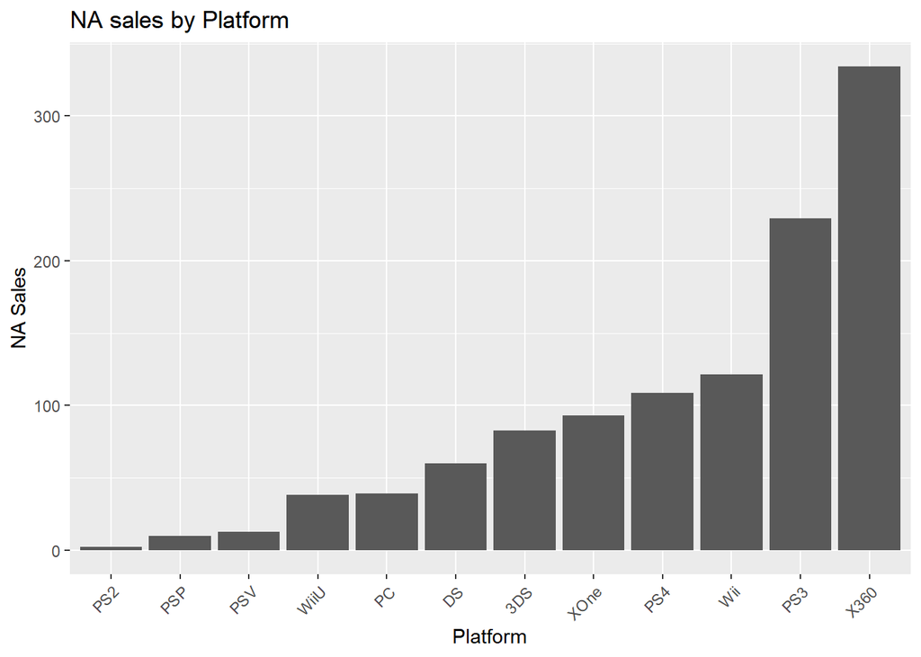

```r
# We use the ggplot2 package to create our graph, the aes() function is used to
# set the aesthetics of the plot. we set our x value to Platform and our Y
# value to NA_total. we also use the reorder() function to reorder the graph
# from smallest to greatest.
ggplot(data = platform_NA_Sales, aes(x = reorder(Platform, NA_total), y = NA_total)) +
    geom_bar(stat = "identity") + labs(title = "NA sales by Platform", x = "Platform",
    y = "NA Sales") + theme(axis.text.x = element_text(angle = 45, hjust = 1))
```

```r
# labs() is used to changes the labels in various parts of the chart. Both the
# X and Y axis changing their names, as well as the title. theme() helps change
# non-data elements of a chart. In this case adding a change to Platform’s axis
# by utilizing element_text() to change the look of texts, adding an angle and
# using hjust to control horizontal justification)
```

This code produces the above graph in which it displays the sum of all Platforms in the 2010 to 2016 range.

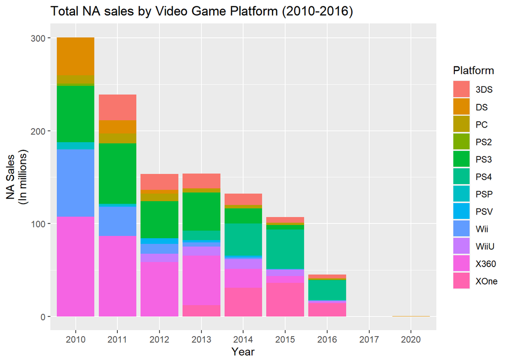

```r
# We use the ggplot2 package to create our graph, the aes() function is used to
# set the aesthetics of the plot. we set our x value to Year_of_Release, our Y
# value to NA_total, and fill based on platform.
ggplot(platform_SalesbyYear, aes(x = Year_of_Release, y = NA_total, fill = Platform)) +
    geom_bar(stat = "identity") + labs(title = "Total NA sales by Video Game Platform (2010-2016)",
    x = "Year", y = "NA Sales\n(In millions)")
```

```r
# labs() is used to changes the labels in various parts of the chart. Both the
# X and Y axis changing their names, as well as the title.
```

This code creates a bar graph that breaks up the total amount of NA sales for each of the different years of each different Platform.

Analysis: Overall, from these graphs we can see that X360 is the most profitable between all these platforms. However, compared to 2010 when it was at its highest, we are able to see that the sales for X360 has been steadily declining same goes for they other platforms as well. But, compared to other platforms it is evident that the PS4 and XOne has both increased in terms of sales since 2010.